# Lab 03 - What should I major in?

Data wrangling and visualization

Jeannie Hinton

2/9/2023

The first step in the process of turning information into knowledge is to summarize and describe the raw information - the data. In this assignment we explore data on college majors and earnings, specifically the data behind the FiveThirtyEight story [“The Economic Guide To Picking A College Major”](https://fivethirtyeight.com/features/the-economic-guide-to-picking-a-college-major/).

These data originally come from the American Community Survey (ACS) 2010-2012 Public Use Microdata Series. While outside the scope of this assignment, if you are curious about how raw data from the ACS were cleaned and prepared, see [the code](https://github.com/fivethirtyeight/data/blob/master/college-majors/college-majors-rscript.R) FiveThirtyEight authors used.

We should also note that there are many considerations that go into picking a major. Earnings potential and employment prospects are two of them, and they are important, but they don’t tell the whole story. Keep this in mind as you analyze the data.

The learning goals of this lab are:

- Manipulate and transform data to prepare it for visualization.
- Summarize data.

## Getting started

Click on the link emailed to you to create your Lab 03 repo, which should be named `lab-03-college-majors-YOUR_NAME`. Copy the URL of the repo, and clone it in RStudio. Refer to Lab 01 if you would like to see step-by-step instructions for cloning a repo into an RStudio project.

First, open the R Markdown document `lab-03-college-majors.Rmd` and Knit it. Make sure it compiles without errors.

# Packages

In this lab we will work with the `tidyverse` package as usual. In addition, we will use the `fivethirtyeight` package for data. You will first need to install the `fivethirtyeight` package by running the command below in your console:

```r
install.packages("fivethirtyeight")
```

Run the following code to load your packages:

```r
library(tidyverse)
library(fivethirtyeight)
```

# The Data

The data frame we will be working with today is called `college_recent_grads` and it’s in the `fivethirtyeight` package.

To find out more about the dataset, type the following in your Console: `?college_recent_grads`. A question mark before the name of an object will always bring up its help file. This command must be run in the Console.

`college_recent_grads` is a tidy **data frame**, with each row representing an **observation** and each column representing a **variable**.

Take a quick peek at your data frame and view its dimensions with the `glimpse` function.

```r
glimpse(college_recent_grads)
```

```
## Rows: 173
## Columns: 21
## $ rank                        <int> 1, 2, 3, 4, 5, 6, 7, 8, 9, 10, 11, 12, 13,…
## $ major_code                  <int> 2419, 2416, 2415, 2417, 2405, 2418, 6202, …
## $ major                       <chr> "Petroleum Engineering", "Mining And Miner…
## $ major_category              <chr> "Engineering", "Engineering", "Engineering…
## $ total                       <int> 2339, 756, 856, 1258, 32260, 2573, 3777, 1…
## $ sample_size                 <int> 36, 7, 3, 16, 289, 17, 51, 10, 1029, 631, …
## $ men                         <int> 2057, 679, 725, 1123, 21239, 2200, 2110, 8…
## $ women                       <int> 282, 77, 131, 135, 11021, 373, 1667, 960, …
## $ sharewomen                  <dbl> 0.1205643, 0.1018519, 0.1530374, 0.1073132…
## $ employed                    <int> 1976, 640, 648, 758, 25694, 1857, 2912, 15…
## $ employed_fulltime           <int> 1849, 556, 558, 1069, 23170, 2038, 2924, 1…
## $ employed_parttime           <int> 270, 170, 133, 150, 5180, 264, 296, 553, 1…
## $ employed_fulltime_yearround <int> 1207, 388, 340, 692, 16697, 1449, 2482, 82…
## $ unemployed                  <int> 37, 85, 16, 40, 1672, 400, 308, 33, 4650, …
## $ unemployment_rate           <dbl> 0.018380527, 0.117241379, 0.024096386, 0.0…
## $ p25th                       <dbl> 95000, 55000, 50000, 43000, 50000, 50000, …
## $ median                      <dbl> 110000, 75000, 73000, 70000, 65000, 65000,…
## $ p75th                       <dbl> 125000, 90000, 105000, 80000, 75000, 10200…
## $ college_jobs                <int> 1534, 350, 456, 529, 18314, 1142, 1768, 97…
## $ non_college_jobs            <int> 364, 257, 176, 102, 4440, 657, 314, 500, 1…
## $ low_wage_jobs               <int> 193, 50, 0, 0, 972, 244, 259, 220, 3253, 3…
```

The description of the variables, i.e. the **codebook**, is given below.

| Header | Description |
| --- | --- |
| `rank` | Rank by median earnings |
| `major_code` | Major code, FO1DP in ACS PUMS |
| `major` | Major description |
| `major_category` | Category of major from Carnevale et al |
| `total` | Total number of people with major |
| `sample_size` | Sample size (unweighted) of full-time, year-round ONLY (used for earnings) |
| `men` | Male graduates |
| `women` | Female graduates |
| `sharewomen` | Women as share of total |
| `employed` | Number employed (ESR == 1 or 2) |
| `employed_full_time` | Employed 35 hours or more |
| `employed_part_time` | Employed less than 35 hours |
| `employed_full_time_yearround` | Employed at least 50 weeks (WKW == 1) and at least 35 hours (WKHP >= 35) |
| `unemployed` | Number unemployed (ESR == 3) |
| `unemployment_rate` | Unemployed / (Unemployed + Employed) |
| `median` | Median earnings of full-time, year-round workers |
| `p25th` | 25th percentile of earnigns |
| `p75th` | 75th percentile of earnings |
| `college_jobs` | Number with job requiring a college degree |
| `non_college_jobs` | Number with job not requiring a college degree |
| `low_wage_jobs` | Number in low-wage service jobs |

The `college_recent_grads` data frame is a trove of information. Let’s think about some questions we might want to answer with these data:

- Which major has the lowest unemployment rate?
- Which major has the highest percentage of women?
- How do the distributions of median income compare across major categories?
- Do women tend to choose majors with lower or higher earnings?

In the next section we aim to answer these questions.

# Data wrangling and visualization

## Which major has the lowest unemployment rate?

In order to answer this question all we need to do is sort the data. We use the `arrange` function to do this, and sort it by the `unemployment_rate` variable. By default `arrange` sorts in ascending order, which is what we want here – we’re interested in the major with the *lowest* unemployment rate.

```r
college_recent_grads %>%
  arrange(unemployment_rate)
```

```
## # A tibble: 173 × 21
##     rank major…¹ major major…² total sampl…³   men women share…⁴ emplo…⁵ emplo…⁶
##    <int>   <int> <chr> <chr>   <int>   <int> <int> <int>   <dbl>   <int>   <int>
##  1    53    4005 Math… Comput…   609       7   500   109   0.179     559     584
##  2    74    3801 Mili… Indust…   124       4   124     0   0           0     111
##  3    84    3602 Bota… Biolog…  1329       9   626   703   0.529    1010     946
##  4   113    1106 Soil… Agricu…   685       4   476   209   0.305     613     488
##  5   121    2301 Educ… Educat…   804       5   280   524   0.652     703     733
##  6    15    2409 Engi… Engine…  4321      30  3526   795   0.184    3608    2999
##  7    20    3201 Cour… Law & …  1148      14   877   271   0.236     930     808
##  8   120    2305 Math… Educat… 14237     123  3872 10365   0.728   13115   11259
##  9     1    2419 Petr… Engine…  2339      36  2057   282   0.121    1976    1849
## 10    65    1100 Gene… Agricu… 10399     158  6053  4346   0.418    8884    7589
## # … with 163 more rows, 10 more variables: employed_parttime <int>,
## #   employed_fulltime_yearround <int>, unemployed <int>,
## #   unemployment_rate <dbl>, p25th <dbl>, median <dbl>, p75th <dbl>,
## #   college_jobs <int>, non_college_jobs <int>, low_wage_jobs <int>, and
## #   abbreviated variable names ¹major_code, ²major_category, ³sample_size,
## #   ⁴sharewomen, ⁵employed, ⁶employed_fulltime
```

This gives us what we wanted, but not in an ideal form. Some of the variables are not that useful (e.g. `major_code`, `major_category`) and some we might want front and center are not easily viewed (e.g. `unemployment_rate`).

We can use the `select` function to choose which variables to display, and in which order:

```r
college_recent_grads %>%
  arrange(unemployment_rate) %>%
  select(unemployment_rate, major, rank)
```

```
## # A tibble: 173 × 3
##    unemployment_rate major                                       rank
##                <dbl> <chr>                                      <int>
##  1           0       Mathematics And Computer Science              53
##  2           0       Military Technologies                         74
##  3           0       Botany                                        84
##  4           0       Soil Science                                 113
##  5           0       Educational Administration And Supervision   121
##  6           0.00633 Engineering Mechanics Physics And Science     15
##  7           0.0117  Court Reporting                               20
##  8           0.0162  Mathematics Teacher Education                120
##  9           0.0184  Petroleum Engineering                          1
## 10           0.0196  General Agriculture                           65
## # … with 163 more rows
```

Ok, this is looking better, but do we really need all those decimal places in the unemployment variable? Not really!

One way to address this problem would be to round the `unemployment_rate` variable in the dataset.

To round `unemployment_rate`: We create a new variable with the `mutate` function. In this case, we’re overwriting the existing `unemployment_rate` variable, by `round`ing it to `4` decimal places.

```r
college_recent_grads %>%
  arrange(unemployment_rate) %>%
  select(major, unemployment_rate, rank) %>%
  mutate(unemployment_rate = round(unemployment_rate, digits = 4))
```

```
## # A tibble: 173 × 3
##    major                                      unemployment_rate  rank
##    <chr>                                                  <dbl> <int>
##  1 Mathematics And Computer Science                      0         53
##  2 Military Technologies                                 0         74
##  3 Botany                                                0         84
##  4 Soil Science                                          0        113
##  5 Educational Administration And Supervision            0        121
##  6 Engineering Mechanics Physics And Science             0.0063    15
##  7 Court Reporting                                       0.0117    20
##  8 Mathematics Teacher Education                         0.0162   120
##  9 Petroleum Engineering                                 0.0184     1
## 10 General Agriculture                                   0.0196    65
## # … with 163 more rows
```

Note that the `digits` in `round` are decimal places.

If we want to keep the formatting change to `unemployment_rate`, we need to save it:

```r
grads <- college_recent_grads %>%
  mutate(unemployment_rate = round(unemployment_rate, digits = 4))
```

## Which major has the highest percentage of women?

To answer such a question we need to arrange the data in descending order. For example, if earlier we were interested in the major with the highest unemployment rate, we would use the following:

```r
grads %>%
  arrange(desc(unemployment_rate)) %>%
  select(major, unemployment_rate, rank)
```

```
## # A tibble: 173 × 3
##    major                                      unemployment_rate  rank
##    <chr>                                                  <dbl> <int>
##  1 Nuclear Engineering                                    0.177     6
##  2 Public Administration                                  0.160    90
##  3 Computer Networking And Telecommunications             0.152    85
##  4 Clinical Psychology                                    0.149   171
##  5 Public Policy                                          0.128    30
##  6 Communication Technologies                             0.120   106
##  7 Mining And Mineral Engineering                         0.117     2
##  8 Computer Programming And Data Processing               0.114    54
##  9 Geography                                              0.114    80
## 10 Architecture                                           0.113    59
## # … with 163 more rows
```

1. Using what you’ve learned so far, arrange the data in descending order with respect to proportion of women in a major, and display only the major, the total number of people with major, and proportion of women. Show only the top 3 majors by adding the `slice` function at the end of the pipeline.

```r
grads %>%
  arrange(desc(women)) %>%
  select(major, total, sharewomen) %>%
  slice(1 : 3)
```

```
## # A tibble: 3 × 3
##   major       total sharewomen
##   <chr>       <int>      <dbl>
## 1 Psychology 393735      0.780
## 2 Nursing    209394      0.896
## 3 Biology    280709      0.602
```

✅ ⬆️ *Commit and push your changes to GitHub with an appropriate commit message. Make sure to commit and push all changed files so that your Git pane is cleared up afterwards.*

## How do the distributions of median income compare across major categories?

There are three types of incomes reported in this data frame: `p25th`, `median`, and `p75th`. These correspond to the 25th, 50th, and 75th percentiles of the income distribution of sampled individuals for a given major.

2. Why do we often choose the median, rather than the mean, to describe the typical income of a group of people? **In regards to a variable such as income where there can be such a large range of values as well as some very low or high extremes, it is best to use the median rather than the mean because the median is not affected by extreme outliers. The mean, however, is affected by outliers and makes it less desriable for assessing the typical income of a group of people.**

The question we want to answer is “How do the distributions of median income compare across major categories?”. We need to do a few things to answer this question: First, we need to group the data by `major_category`. Then, we need a way to summarize the distributions of median income within these groups. This decision will depend on the shapes of these distributions. So first, we need to visualize the data.

We use the `ggplot` function to do this. The first argument is the data frame, and the next argument gives the mapping of the variables of the data to the `aes`thetic elements of the plot.

Let’s start simple and take a look at the distribution of all median incomes, without considering the major categories.

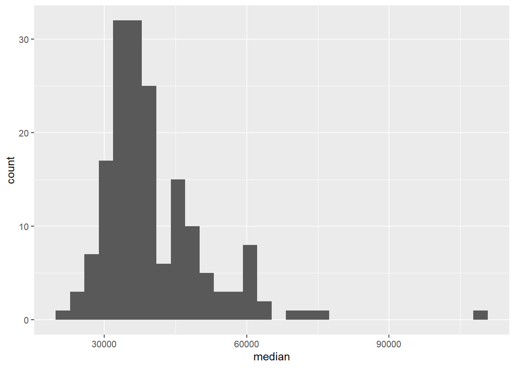

```r
ggplot(data = grads, mapping = aes(x = median)) +
  geom_histogram()
```

Along with the plot, we get a message:

```
`stat_bin()` using `bins = 30`. Pick better value with `binwidth`.
```

This is telling us that we might want to reconsider the bin width we chose for our histogram – or more accurately, the bin width we didn’t specify. It’s good practice to always think in the context of the data and try out a few bin widths before settling on one. You might ask yourself: “What would be a meaningful difference in median incomes?” $1 is obviously too little, $10000 might be too high.

3. Modify the histogram plotting code above (the distribution of all median incomes) and try bin widths of $1000 and $5000. Choose the binwidth that you think is most appropriate. Explain your reasoning for your choice. Note that the binwidth is an argument for the `geom_histogram` function. So to specify a binwidth of $1000, you would use `geom_histogram(binwidth = 1000)`.

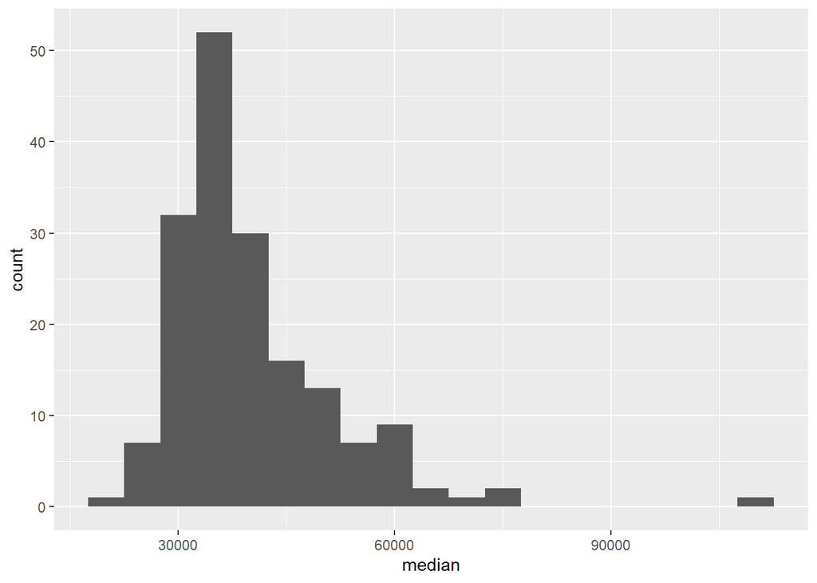

```r
ggplot(data = grads, mapping = aes(x = median)) +
  geom_histogram(binwidth = 5000)
```

✅ ⬆️ *Commit and push your changes to GitHub with an appropriate commit message again. Make sure to commit and push all changed files so that your Git pane is cleared up afterwards.*

We can also calculate summary statistics for this distribution using the `summarize` function:

```r
grads %>%
  summarize(min = min(median), max = max(median),
            mean = mean(median), med = median(median),
            sd = sd(median),
            q1 = quantile(median, probs = 0.25),
            q3 = quantile(median, probs = 0.75))
```

```
## # A tibble: 1 × 7
##     min    max   mean   med     sd    q1    q3
##   <dbl>  <dbl>  <dbl> <dbl>  <dbl> <dbl> <dbl>
## 1 22000 110000 40151. 36000 11470. 33000 45000
```

4. Based on the shape of the histogram you created in the previous exercise, determine which of these summary statistics is useful for describing the center of the distribution. Write up your description of the distribution (remember shape, center, spread, any unusual observations) and include the summary statistic that you chose as well.

**The median of the median is a useful measure of center for this dataset because of the large range of values for income and the variation in frequency of the levels of income. To explain, the frequency for incomes above $90000 is so low compared to the frequency of those with an income of around $30000 so the median helps negate the issues that could have been caused by such variation in frequency of income levels.**

Next, we facet the plot by major category.

5. Plot the distribution of `median` income using a histogram, faceted by `major_category`. Use the `binwidth` you chose in the earlier exercise. If the major category labels in your faceted plot aren’t displaying nicely, try adding the option `labeller = label_wrap_gen(width = 15)` to your `facet_grid()` or `facet_wrap()` function call.

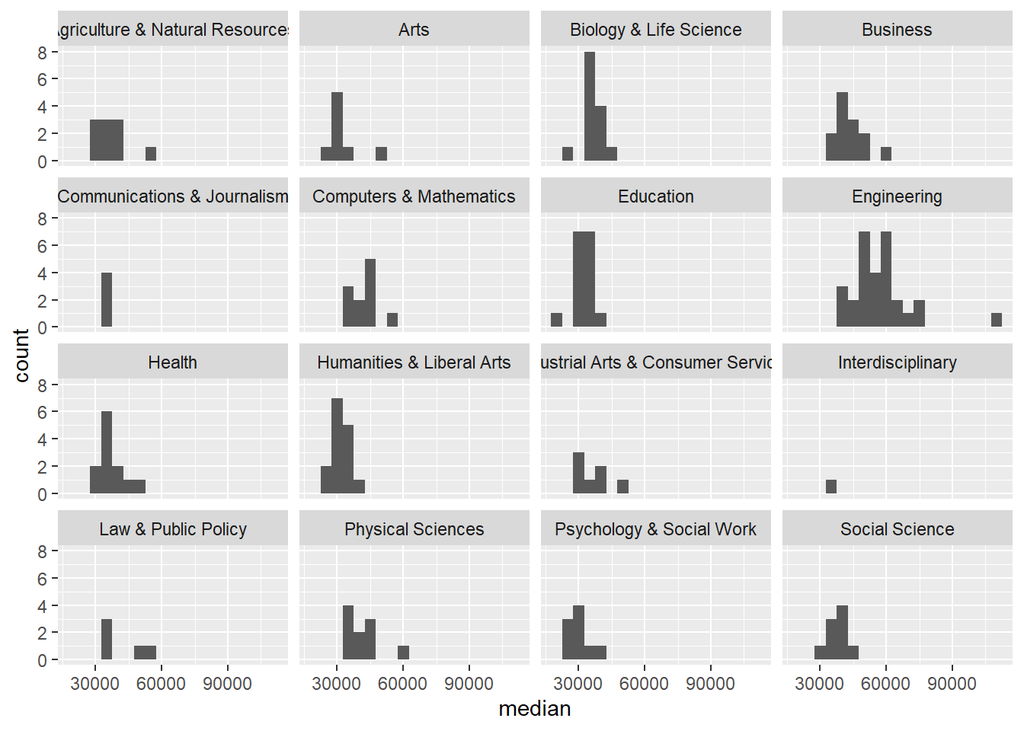

```r
ggplot(data = grads, mapping = aes(x = median)) +
  geom_histogram(binwidth = 5000) +
  facet_wrap(~ major_category)
```

Next, use side-by-side boxplots to visualize the distribution of `median` income by `major_category`. Hint: since the `major_category` values are somewhat lengthy, you might consider plotting that variable on the y-axis. Which visualization do you think is more effective: the side-by-side histograms, or the side-by-side boxplots?

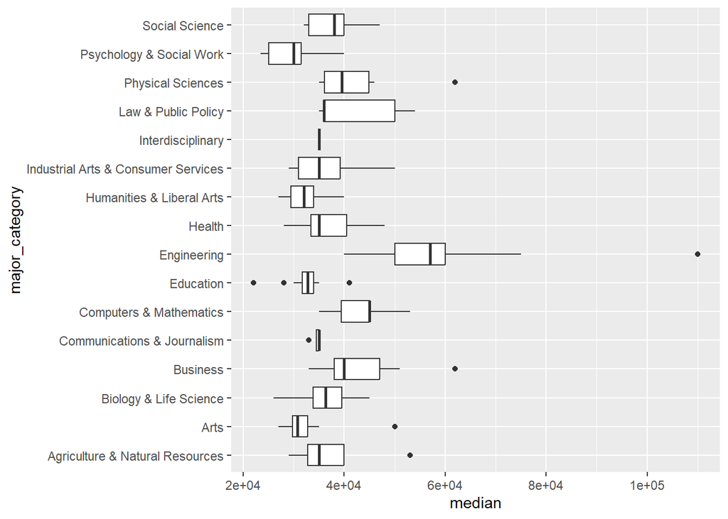

```r
ggplot(data = grads, mapping = aes(x = median, y = major_category)) +
  geom_boxplot()
```

**I believe that the side-by-side boxplots are much easier to understand compared to the side-by-side histograms because I can more easily compare the range of salaries as well as where the middle 50% of each major’s income is. It is much more difficult to see where the middle 50% of observations for each major fall in the histograms. With the boxplots, I can also see exactly where the median income is for each major, which is a very informative summary statistic that I cannot find with the histograms.**

Now that we’ve seen the shapes of the distributions of median incomes for each major category, we should have a better idea for which summary statistic to use to quantify the typical median income.

6. Which major category has the highest typical (you’ll need to decide what this means) median income? Use the partial code below, filling it in with the appropriate statistic and function. Also note that we are looking for the highest statistic, so make sure to arrange in the correct direction.

```r
grads %>%
  group_by(major_category) %>%
  summarize(typical_median = median(median)) %>%
  arrange(desc(typical_median))
```

```
## # A tibble: 16 × 2
##    major_category                      typical_median
##    <chr>                                        <dbl>
##  1 Engineering                                  57000
##  2 Computers & Mathematics                      45000
##  3 Business                                     40000
##  4 Physical Sciences                            39500
##  5 Social Science                               38000
##  6 Biology & Life Science                       36300
##  7 Law & Public Policy                          36000
##  8 Agriculture & Natural Resources              35000
##  9 Communications & Journalism                  35000
## 10 Health                                       35000
## 11 Industrial Arts & Consumer Services          35000
## 12 Interdisciplinary                            35000
## 13 Education                                    32750
## 14 Humanities & Liberal Arts                    32000
## 15 Arts                                         30750
## 16 Psychology & Social Work                     30000
```

**Engineering has the highest typical median income.**

✅ ⬆️ *Commit and push your changes to GitHub with an appropriate commit message again. Make sure to commit and push all changed files so that your Git pane is cleared up afterwards.*

7. Which major category is the least popular in this sample? To answer this question we use a function called `count`, which first groups the data and then counts the number of observations in each category (see below). Add to the pipeline appropriately to arrange the results so that the major category with the lowest observations is on top.

```r
grads %>%
  count(major_category) %>%
  arrange(n)
```

```
## # A tibble: 16 × 2
##    major_category                          n
##    <chr>                               <int>
##  1 Interdisciplinary                       1
##  2 Communications & Journalism             4
##  3 Law & Public Policy                     5
##  4 Industrial Arts & Consumer Services     7
##  5 Arts                                    8
##  6 Psychology & Social Work                9
##  7 Social Science                          9
##  8 Agriculture & Natural Resources        10
##  9 Physical Sciences                      10
## 10 Computers & Mathematics                11
## 11 Health                                 12
## 12 Business                               13
## 13 Biology & Life Science                 14
## 14 Humanities & Liberal Arts              15
## 15 Education                              16
## 16 Engineering                            29
```

One of the sections of the [FiveThirtyEight story](https://fivethirtyeight.com/features/the-economic-guide-to-picking-a-college-major/) is “All STEM fields aren’t the same”. Let’s see if this is true.

First, let’s create a new vector called `stem_categories` that lists the major categories that are considered STEM fields.

```r
stem_categories <- c("Biology & Life Science",
                     "Computers & Mathematics",
                     "Engineering",
                     "Physical Sciences")
```

Then, we can use this to create a new variable in our data frame indicating whether a major is STEM or not.

```r
grads <- grads %>%
  mutate(major_type =
           ifelse(major_category %in% stem_categories, "stem", "not stem"))
glimpse(grads)
```

```
## Rows: 173
## Columns: 22
## $ rank                        <int> 1, 2, 3, 4, 5, 6, 7, 8, 9, 10, 11, 12, 13,…
## $ major_code                  <int> 2419, 2416, 2415, 2417, 2405, 2418, 6202, …
## $ major                       <chr> "Petroleum Engineering", "Mining And Miner…
## $ major_category              <chr> "Engineering", "Engineering", "Engineering…
## $ total                       <int> 2339, 756, 856, 1258, 32260, 2573, 3777, 1…
## $ sample_size                 <int> 36, 7, 3, 16, 289, 17, 51, 10, 1029, 631, …
## $ men                         <int> 2057, 679, 725, 1123, 21239, 2200, 2110, 8…
## $ women                       <int> 282, 77, 131, 135, 11021, 373, 1667, 960, …
## $ sharewomen                  <dbl> 0.1205643, 0.1018519, 0.1530374, 0.1073132…
## $ employed                    <int> 1976, 640, 648, 758, 25694, 1857, 2912, 15…
## $ employed_fulltime           <int> 1849, 556, 558, 1069, 23170, 2038, 2924, 1…
## $ employed_parttime           <int> 270, 170, 133, 150, 5180, 264, 296, 553, 1…
## $ employed_fulltime_yearround <int> 1207, 388, 340, 692, 16697, 1449, 2482, 82…
## $ unemployed                  <int> 37, 85, 16, 40, 1672, 400, 308, 33, 4650, …
## $ unemployment_rate           <dbl> 0.0184, 0.1172, 0.0241, 0.0501, 0.0611, 0.…
## $ p25th                       <dbl> 95000, 55000, 50000, 43000, 50000, 50000, …
## $ median                      <dbl> 110000, 75000, 73000, 70000, 65000, 65000,…
## $ p75th                       <dbl> 125000, 90000, 105000, 80000, 75000, 10200…
## $ college_jobs                <int> 1534, 350, 456, 529, 18314, 1142, 1768, 97…
## $ non_college_jobs            <int> 364, 257, 176, 102, 4440, 657, 314, 500, 1…
## $ low_wage_jobs               <int> 193, 50, 0, 0, 972, 244, 259, 220, 3253, 3…
## $ major_type                  <chr> "stem", "stem", "stem", "stem", "stem", "s…
```

Let’s unpack this: with `mutate` we create a new variable called `major_type`, which is defined as `"stem"` if the `major_category` is in the vector called `stem_categories` we created earlier, and as `"not stem"` otherwise.

`%in%` is a **logical operator**. Other logical operators that are commonly used are

| Operator | Operation |
| --- | --- |
| `x < y` | less than |
| `x > y` | greater than |
| `x <= y` | less than or equal to |
| `x >= y` | greater than or equal to |
| `x != y` | not equal to |
| `x == y` | equal to |
| `x %in% y` | contains |
| `x \| y` | or |
| `x & y` | and |
| `!x` | not |

We can use the logical operators to also `filter` our data for STEM majors whose median earnings is less than or equal to the median for all majors’ median earnings, which we found to be $36,000 earlier.

```r
grads %>%
  filter(
    major_type == "stem",
    median <= 36000
  )
```

```
## # A tibble: 11 × 22
##     rank major_code major   major…¹  total sampl…²    men  women share…³ emplo…⁴
##    <int>      <int> <chr>   <chr>    <int>   <int>  <int>  <int>   <dbl>   <int>
##  1    91       5005 Geosci… Physic…   1978      18    809   1169   0.591    1441
##  2    93       1301 Enviro… Biolog…  25965     225  10787  15178   0.585   20859
##  3    98       5098 Multi-… Physic…  62052     427  27015  35037   0.565   46138
##  4   102       3608 Physio… Biolog…  22060      99   8422  13638   0.618   14643
##  5   106       2001 Commun… Comput…  18035     208  11431   6604   0.366   14779
##  6   109       3611 Neuros… Biolog…  13663      53   4944   8719   0.638    9087
##  7   111       5002 Atmosp… Physic…   4043      32   2744   1299   0.321    3431
##  8   123       3699 Miscel… Biolog…  10706      63   4747   5959   0.557    7767
##  9   124       3600 Biology Biolog… 280709    1370 111762 168947   0.602  182295
## 10   133       3604 Ecology Biolog…   9154      86   3878   5276   0.576    7585
## 11   169       3609 Zoology Biolog…   8409      47   3050   5359   0.637    6259
## # … with 12 more variables: employed_fulltime <int>, employed_parttime <int>,
## #   employed_fulltime_yearround <int>, unemployed <int>,
## #   unemployment_rate <dbl>, p25th <dbl>, median <dbl>, p75th <dbl>,
## #   college_jobs <int>, non_college_jobs <int>, low_wage_jobs <int>,
## #   major_type <chr>, and abbreviated variable names ¹major_category,
## #   ²sample_size, ³sharewomen, ⁴employed
```

8. Which STEM majors have median salaries equal to or less than the median for all majors’ median earnings? Your output should only show the major name and median, 25th percentile, and 75th percentile earning for that major and should be sorted such that the major with the highest median earning is on top.

```r
grads %>%
  summarize(median_income = median(median))
```

```
## # A tibble: 1 × 1
##   median_income
##           <dbl>
## 1         36000
```

```r
grads %>%
  filter(
    major_type == "stem",
    median <= median(median)) %>%
  select(major_category, median, p25th, p75th) %>%
  arrange(desc(median))
```

```
## # A tibble: 11 × 4
##    major_category          median p25th p75th
##    <chr>                    <dbl> <dbl> <dbl>
##  1 Physical Sciences        36000 21000 41000
##  2 Biology & Life Science   35600 25000 40200
##  3 Physical Sciences        35000 24000 50000
##  4 Biology & Life Science   35000 20000 50000
##  5 Computers & Mathematics  35000 25000 45000
##  6 Biology & Life Science   35000 30000 44000
##  7 Physical Sciences        35000 28000 50000
##  8 Biology & Life Science   33500 23000 48000
##  9 Biology & Life Science   33400 24000 45000
## 10 Biology & Life Science   33000 23000 42000
## 11 Biology & Life Science   26000 20000 39000
```

✅ ⬆️ *Commit and push your changes to GitHub with an appropriate commit message again. Make sure to commit and push all changed files so that your Git pane is cleared up afterwards.*

## What types of majors do women tend to major in?

9. Create a scatterplot of median income vs. proportion of women in that major, colored by whether the major is in a STEM field or not. Describe the association between these three variables.

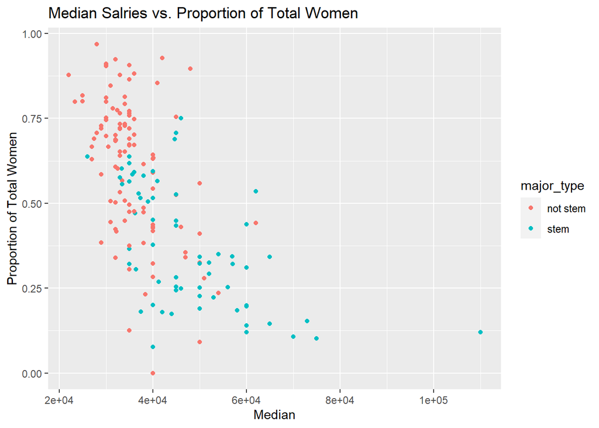

```r
ggplot(data = grads, mapping = aes(x = median, y = sharewomen, color = major_type)) +
  geom_point() +
  labs(title = "Median Salries vs. Proportion of Total Women",
       x = "Median",
       y = "Proportion of Total Women")
```

10. Ask a question of interest to you and answer it using summary statistic(s) and/or visualization(s).

```r
grads %>%
  filter(
    median(median) <= 60000) %>%
  select(major_category, median) %>%
  arrange(desc(median))
```

```
## # A tibble: 173 × 2
##    major_category    median
##    <chr>              <dbl>
##  1 Engineering       110000
##  2 Engineering        75000
##  3 Engineering        73000
##  4 Engineering        70000
##  5 Engineering        65000
##  6 Engineering        65000
##  7 Business           62000
##  8 Physical Sciences  62000
##  9 Engineering        60000
## 10 Engineering        60000
## # … with 163 more rows
```

✅ ⬆️ *Commit and push your changes to GitHub with an appropriate commit message again. Make sure to commit and push all changed files so that your Git pane is cleared up afterwards.*

## Wrapping up

Go back through your write up to make sure you’re following coding style guidelines we discussed in class. Make any edits as needed.

Also, make sure all of your R chunks are properly labeled, and your figures are reasonably sized.